# CASE_3

Liam Phan, Michael Bigler, Tania Loureiro, William Elkiess, Dakota Cuellar and Ilyana El Mendili

2023-05-03

```r
library(DT)
library(summarytools)
library(corrplot)
library(dplyr)
library(GGally)
library(fastDummies)
library(ggcorrplot)
library(klaR)
library(psych)
library(MASS)
# library(ggord)
library(devtools)
CM_Function <- function(cm) {

  layout(matrix(c(1,1,2)))
  par(mar=c(2,2,2,2))
  plot(c(100, 345), c(300, 450), type = "n", xlab="", ylab="", xaxt='n', yaxt='n')
  title('CONFUSION MATRIX', cex.main=2)

  # create the matrix
  rect(150, 430, 240, 370, col='#2F4F4E')
  text(195, 435, 'No', cex=1.2)
  rect(250, 430, 340, 370, col='#0D8387')
  text(295, 435, 'Yes', cex=1.2)
  text(125, 370, 'Predicted', cex=1.3, srt=90, font=2)
  text(245, 450, 'Actual', cex=1.3, font=2)
  rect(150, 305, 240, 365, col='#0D8387')
  rect(250, 305, 340, 365, col='#2F4F4E')
  text(140, 400, 'No', cex=1.2, srt=90)
  text(140, 335, 'Yes', cex=1.2, srt=90)

  # add in the cm results
  res <- as.numeric(cm$table)
  text(195, 400, res[1], cex=1.6, font=2, col='white')
  text(195, 335, res[2], cex=1.6, font=2, col='white')
  text(295, 400, res[3], cex=1.6, font=2, col='white')
  text(295, 335, res[4], cex=1.6, font=2, col='white')

  # add in the specifics
  plot(c(100, 0), c(100, 0), type = "n", xlab="", ylab="", main = "DETAILS", xaxt='n', yaxt='n')
  text(10, 85, names(cm$byClass[1]), cex=1.2, font=2)
  text(10, 70, round(as.numeric(cm$byClass[1]), 3), cex=1.2)
  text(30, 85, names(cm$byClass[2]), cex=1.2, font=2)
  text(30, 70, round(as.numeric(cm$byClass[2]), 3), cex=1.2)
  text(50, 85, names(cm$byClass[5]), cex=1.2, font=2)
  text(50, 70, round(as.numeric(cm$byClass[5]), 3), cex=1.2)
  text(70, 85, names(cm$byClass[6]), cex=1.2, font=2)
  text(70, 70, round(as.numeric(cm$byClass[6]), 3), cex=1.2)
  text(90, 85, names(cm$byClass[7]), cex=1.2, font=2)
  text(90, 70, round(as.numeric(cm$byClass[7]), 3), cex=1.2)

  # add in the accuracy information
  text(30, 35, names(cm$overall[1]), cex=1.5, font=2)
  text(30, 20, round(as.numeric(cm$overall[1]), 3), cex=1.4)
  text(70, 35, names(cm$overall[2]), cex=1.5, font=2)
  text(70, 20, round(as.numeric(cm$overall[2]), 3), cex=1.4)
}

#options(repos = c(
    #fawda123 = 'https://fawda123.r-universe.dev',
    #CRAN = 'https://cloud.r-project.org'))

# Install ggord
#install.packages('ggord')
```

# Data and Feature Engineering

```r
df <- readxl::read_xls('Cchurn.xls')
df$international_plan <- factor(df$international_plan, levels = c('no', 'yes'))
df$voice_mail_plan <- factor(df$voice_mail_plan, levels = c('no', 'yes'))
df$churn <- factor(df$churn, levels = c('no', 'yes'))
```

## Summary

```r
print(summarytools::dfSummary(df), method = 'render')
```

Data Frame Summary

df

**Dimensions**: 5000 x 18  
**Duplicates**: 0

| **No** | **Variable** | **Stats / Values** | **Freqs (% of Valid)** | **Graph** | **Valid** | **Missing** |
| --- | --- | --- | --- | --- | --- | --- |
| 1 | account_length [numeric] | Mean (sd) : 100.3 (39.7) min ≤ med ≤ max: 1 ≤ 100 ≤ 243 IQR (CV) : 54 (0.4) | 218 distinct values |  | 5000 (100.0%) | 0 (0.0%) |
| 2 | international_plan [factor] | 1. no 2. yes | 4527 ( 90.5% ) 473 ( 9.5% ) |  | 5000 (100.0%) | 0 (0.0%) |
| 3 | voice_mail_plan [factor] | 1. no 2. yes | 3677 ( 73.5% ) 1323 ( 26.5% ) |  | 5000 (100.0%) | 0 (0.0%) |
| 4 | number_vmail_messages [numeric] | Mean (sd) : 7.8 (13.5) min ≤ med ≤ max: 0 ≤ 0 ≤ 52 IQR (CV) : 17 (1.7) | 48 distinct values |  | 5000 (100.0%) | 0 (0.0%) |
| 5 | total_day_minutes [numeric] | Mean (sd) : 180.3 (53.9) min ≤ med ≤ max: 0 ≤ 180.1 ≤ 351.5 IQR (CV) : 72.5 (0.3) | 1961 distinct values |  | 5000 (100.0%) | 0 (0.0%) |
| 6 | total_day_calls [numeric] | Mean (sd) : 100 (19.8) min ≤ med ≤ max: 0 ≤ 100 ≤ 165 IQR (CV) : 26 (0.2) | 123 distinct values |  | 5000 (100.0%) | 0 (0.0%) |
| 7 | total_day_charge [numeric] | Mean (sd) : 30.6 (9.2) min ≤ med ≤ max: 0 ≤ 30.6 ≤ 59.8 IQR (CV) : 12.3 (0.3) | 1961 distinct values |  | 5000 (100.0%) | 0 (0.0%) |
| 8 | total_eve_minutes [numeric] | Mean (sd) : 200.6 (50.6) min ≤ med ≤ max: 0 ≤ 201 ≤ 363.7 IQR (CV) : 67.7 (0.3) | 1879 distinct values |  | 5000 (100.0%) | 0 (0.0%) |
| 9 | total_eve_calls [numeric] | Mean (sd) : 100.2 (19.8) min ≤ med ≤ max: 0 ≤ 100 ≤ 170 IQR (CV) : 27 (0.2) | 126 distinct values |  | 5000 (100.0%) | 0 (0.0%) |
| 10 | total_eve_charge [numeric] | Mean (sd) : 17.1 (4.3) min ≤ med ≤ max: 0 ≤ 17.1 ≤ 30.9 IQR (CV) : 5.8 (0.3) | 1659 distinct values |  | 5000 (100.0%) | 0 (0.0%) |
| 11 | total_night_minutes [numeric] | Mean (sd) : 200.4 (50.5) min ≤ med ≤ max: 0 ≤ 200.4 ≤ 395 IQR (CV) : 67.8 (0.3) | 1853 distinct values |  | 5000 (100.0%) | 0 (0.0%) |
| 12 | total_night_calls [numeric] | Mean (sd) : 99.9 (20) min ≤ med ≤ max: 0 ≤ 100 ≤ 175 IQR (CV) : 26 (0.2) | 131 distinct values |  | 5000 (100.0%) | 0 (0.0%) |
| 13 | total_night_charge [numeric] | Mean (sd) : 9 (2.3) min ≤ med ≤ max: 0 ≤ 9 ≤ 17.8 IQR (CV) : 3.1 (0.3) | 1028 distinct values |  | 5000 (100.0%) | 0 (0.0%) |
| 14 | total_intl_minutes [numeric] | Mean (sd) : 10.3 (2.8) min ≤ med ≤ max: 0 ≤ 10.3 ≤ 20 IQR (CV) : 3.5 (0.3) | 170 distinct values |  | 5000 (100.0%) | 0 (0.0%) |
| 15 | total_intl_calls [numeric] | Mean (sd) : 4.4 (2.5) min ≤ med ≤ max: 0 ≤ 4 ≤ 20 IQR (CV) : 3 (0.6) | 21 distinct values |  | 5000 (100.0%) | 0 (0.0%) |
| 16 | total_intl_charge [numeric] | Mean (sd) : 2.8 (0.7) min ≤ med ≤ max: 0 ≤ 2.8 ≤ 5.4 IQR (CV) : 0.9 (0.3) | 170 distinct values |  | 5000 (100.0%) | 0 (0.0%) |
| 17 | number_customer_service_calls [numeric] | Mean (sd) : 1.6 (1.3) min ≤ med ≤ max: 0 ≤ 1 ≤ 9 IQR (CV) : 1 (0.8) | 0 : 1023 ( 20.5% ) 1 : 1786 ( 35.7% ) 2 : 1127 ( 22.5% ) 3 : 665 ( 13.3% ) 4 : 252 ( 5.0% ) 5 : 96 ( 1.9% ) 6 : 34 ( 0.7% ) 7 : 13 ( 0.3% ) 8 : 2 ( 0.0% ) 9 : 2 ( 0.0% ) |  | 5000 (100.0%) | 0 (0.0%) |
| 18 | churn [factor] | 1. no 2. yes | 4293 ( 85.9% ) 707 ( 14.1% ) |  | 5000 (100.0%) | 0 (0.0%) |

Generated by summarytools 1.0.1 ([R](https://www.r-project.org/) version 4.2.3)  
2023-05-03

- We have no missing values -> perfect
- Heavily uneven counts of dependent variable (86 % no / 14 % yes) -> maybe sample for equality / maybe not because we loose information of other data
- Independent variables are on different scales -> standardize
- two (maybe three) categorical predictors: International plan / voice_mail_plan (/ maybe number_customer_service_calls) -> dummy encode -> not necessary as already 0 and 1
- Rest of data is numeric and most of the variables looks normally distributed with exception of number_vmail_messages and totat_intl_calls
  - transform these value to make them normal?
  - maybe make parts of them categorical? (recieving voice mail or not, calling internationally or not)
  - or maybe the categorical values that we have already give an indication for this
  - Test normality of variables
- Can variables be combined? We have day / eve / night / intl calls and for each of them minutes / calls / charge. Maybe we can combine this into one metric. Maybe average cost per minute or average cost per call?

## Correlation Plot

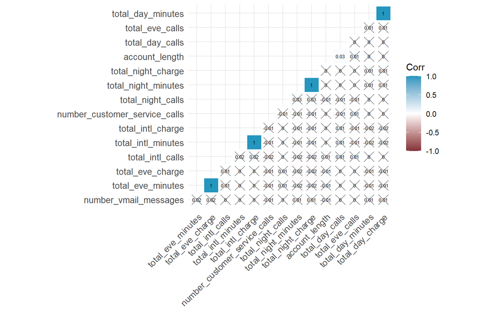

```r
df_numeric <- select_if(df, is.numeric)  # Subset numeric columns with dplyr

M <- cor(df_numeric)

p.mat <- cor_pmat(df_numeric)

ggcorrplot(M, hc.order = TRUE, type = "lower", lab = TRUE, p.mat = p.mat, sig.level=0.05, lab_size = 2, tl.cex = 10,outline.col = "white", ggtheme = ggplot2::theme_minimal(), colors = c("#823038", "white", "#2596be"))
```

Proves theory from before -> we can make one metric out of charge and minutes –> charge / minutes

## Data Engineering

```r
df$total_day_charge_per_minute <- ifelse(df$total_day_minutes == 0, 0, df$total_day_charge / df$total_day_minutes)
df$total_eve_charge_per_minute <- ifelse(df$total_eve_minutes == 0, 0, df$total_eve_charge / df$total_eve_minutes)
df$total_night_charge_per_minute <- ifelse(df$total_night_minutes == 0, 0, df$total_night_charge / df$total_night_minutes)
df$total_intl_charge_per_minute <- ifelse(df$total_intl_minutes == 0, 0, df$total_intl_charge / df$total_intl_minutes)
df <- subset(df, select = -c(total_day_charge, total_day_minutes, total_eve_charge, total_eve_minutes, total_night_charge, total_night_minutes, total_intl_charge, total_intl_minutes))
```

## Correlation Plot

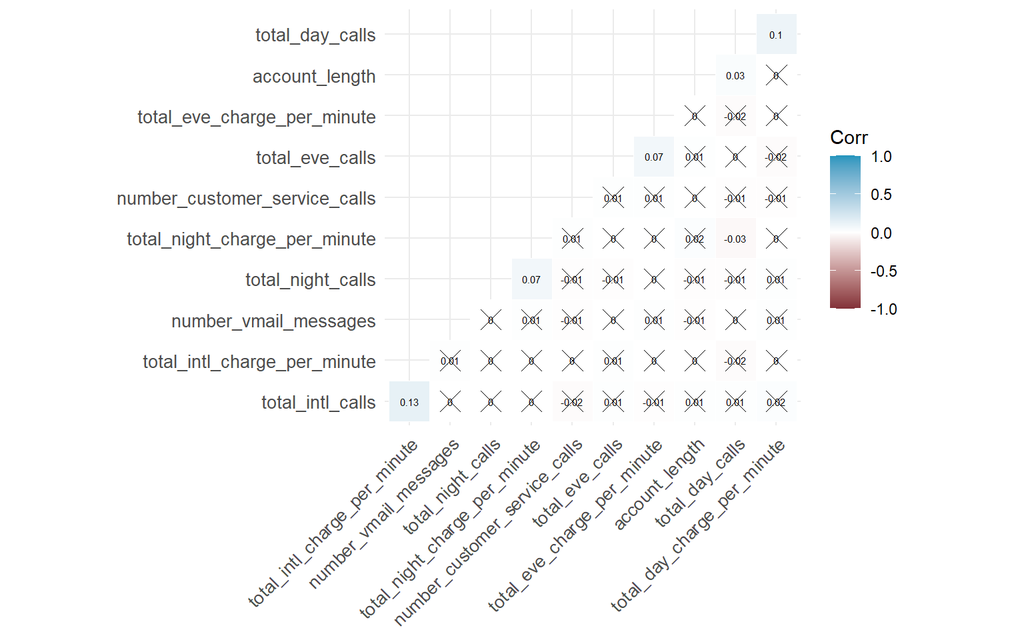

```r
df_numeric <- select_if(df, is.numeric)  # Subset numeric columns with dplyr

M <- cor(df_numeric)

p.mat <- cor_pmat(df_numeric)

ggcorrplot(M, hc.order = TRUE, type = "lower", lab = TRUE, p.mat = p.mat, sig.level=0.05, lab_size = 2, tl.cex = 10,outline.col = "white", ggtheme = ggplot2::theme_minimal(), colors = c("#823038", "white", "#2596be"))
```

Now we have non-correlated data

## Scale

```r
df <- df %>% mutate_if(~!is.factor(.), ~(scale(.) %>% as.vector))
```

# Predicting Models

## Logistic Regression

```r
mod <- glm(churn ~., data = df, family = binomial(link='logit'))
summary(mod)
```

```
FALSE
FALSE Call:
FALSE glm(formula = churn ~ ., family = binomial(link = "logit"), data = df)
FALSE
FALSE Deviance Residuals:
FALSE     Min       1Q   Median       3Q      Max
FALSE -1.7457  -0.5394  -0.4111  -0.2814   2.9316
FALSE
FALSE Coefficients:
FALSE                               Estimate Std. Error z value             Pr(>|z|)
FALSE (Intercept)                   -1.79131    0.12233 -14.643 < 0.0000000000000002
FALSE account_length                 0.05015    0.04369   1.148              0.25103
FALSE international_planyes          1.96147    0.11297  17.362 < 0.0000000000000002
FALSE voice_mail_planyes            -1.90956    0.45233  -4.222            0.0000243
FALSE number_vmail_messages          0.41827    0.19086   2.192              0.02841
FALSE total_day_calls                0.06170    0.04391   1.405              0.15999
FALSE total_eve_calls               -0.02729    0.04398  -0.620              0.53502
FALSE total_night_calls             -0.01252    0.04399  -0.285              0.77593
FALSE total_intl_calls              -0.16467    0.04766  -3.455              0.00055
FALSE number_customer_service_calls  0.58987    0.03995  14.766 < 0.0000000000000002
FALSE total_day_charge_per_minute   -0.03650    0.03079  -1.185              0.23597
FALSE total_eve_charge_per_minute    0.05848    0.31662   0.185              0.85347
FALSE total_night_charge_per_minute  0.04800    0.22938   0.209              0.83426
FALSE total_intl_charge_per_minute   0.11895    0.07432   1.601              0.10948
FALSE
FALSE (Intercept)                   ***
FALSE account_length
FALSE international_planyes         ***
FALSE voice_mail_planyes            ***
FALSE number_vmail_messages         *
FALSE total_day_calls
FALSE total_eve_calls
FALSE total_night_calls
FALSE total_intl_calls              ***
FALSE number_customer_service_calls ***
FALSE total_day_charge_per_minute
FALSE total_eve_charge_per_minute
FALSE total_night_charge_per_minute
FALSE total_intl_charge_per_minute
FALSE ---
FALSE Signif. codes:  0 '***' 0.001 '**' 0.01 '*' 0.05 '.' 0.1 ' ' 1
FALSE
FALSE (Dispersion parameter for binomial family taken to be 1)
FALSE
FALSE     Null deviance: 4075.0  on 4999  degrees of freedom
FALSE Residual deviance: 3495.9  on 4986  degrees of freedom
FALSE AIC: 3523.9
FALSE
FALSE Number of Fisher Scoring iterations: 7
```

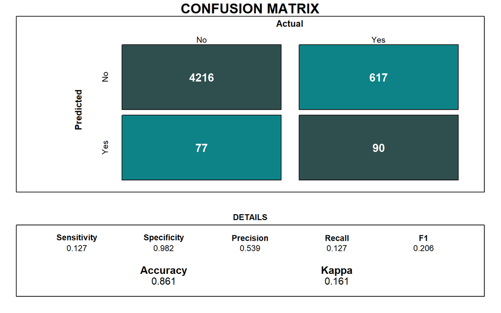

```r
churn_predicted <- factor(ifelse(predict(mod, df[,-c(10)], type = 'response') < 0.5, 'no', 'yes'))

library(caret)
LR_Confusion_Matrix_training <- confusionMatrix(data=churn_predicted, reference = df$churn, positive = 'yes')

CM_Function(LR_Confusion_Matrix_training)
```

Log regression doesn’t work. Changing the decision boundary also doesn’t help. –> maybe we actually need to resample

## LDA

```r
set.seed(1)

# Row Sample
ind <- sample(2, nrow(df),
              replace = TRUE,
              prob = c(0.6, 0.4))

# Training 60%
training <- df[ind==1,]

# Testing 40%
testing <- df[ind==2,]

# LDA Model Fit on Training
LDA_training <- lda(churn~., training)
LDA_training
```

```
FALSE Call:
FALSE lda(churn ~ ., data = training)
FALSE
FALSE Prior probabilities of groups:
FALSE        no       yes
FALSE 0.8609836 0.1390164
FALSE
FALSE Group means:
FALSE     account_length international_planyes voice_mail_planyes
FALSE no     -0.01041928            0.06016756          0.2760853
FALSE yes     0.09104627            0.29009434          0.1438679
FALSE     number_vmail_messages total_day_calls total_eve_calls total_night_calls
FALSE no             0.01565366      0.02150280    -0.005196759        0.00599450
FALSE yes           -0.23977781      0.07035018     0.003927468       -0.03423827
FALSE     total_intl_calls number_customer_service_calls total_day_charge_per_minute
FALSE no         0.0190908                   -0.06992266                  0.02012463
FALSE yes       -0.1339423                    0.41009424                 -0.09819911
FALSE     total_eve_charge_per_minute total_night_charge_per_minute
FALSE no                  -0.01276627                   -0.01341850
FALSE yes                  0.01396401                    0.01455398
FALSE     total_intl_charge_per_minute
FALSE no                  -0.001687723
FALSE yes                  0.035411240
FALSE
FALSE Coefficients of linear discriminants:
FALSE                                        LD1
FALSE account_length                 0.109952886
FALSE international_planyes          2.902441023
FALSE voice_mail_planyes            -1.179083128
FALSE number_vmail_messages          0.214628535
FALSE total_day_calls                0.058929902
FALSE total_eve_calls                0.006096775
FALSE total_night_calls             -0.032326821
FALSE total_intl_calls              -0.176213915
FALSE number_customer_service_calls  0.519021094
FALSE total_day_charge_per_minute   -0.135296273
FALSE total_eve_charge_per_minute    0.012329800
FALSE total_night_charge_per_minute  0.014752007
FALSE total_intl_charge_per_minute   0.065819211
```

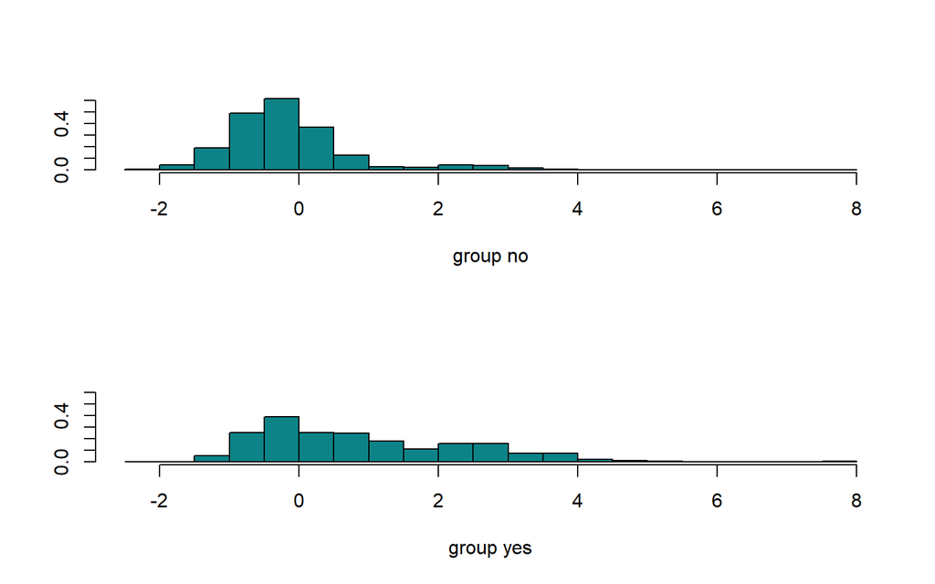

```r
# Density Plot for Overlapping
p <- predict(LDA_training, training)
ldahist(data = p$x[,1], g = training$churn, col = "#0D8387")
```

### Confusion Matrix (Training VS Test)

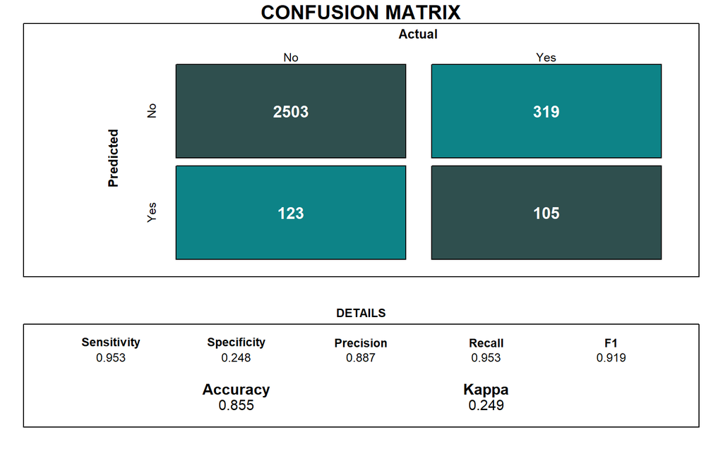

```r
# Training 60%
LDA_predictions_training <- predict(LDA_training, training)$class

LDA_Confusion_Matrix_training <- confusionMatrix(data = LDA_predictions_training, reference = training$churn)

CM_Function(LDA_Confusion_Matrix_training)
```

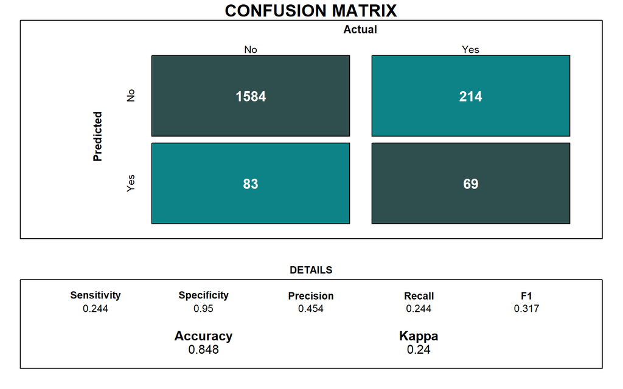

```r
# Testing 40%
LDA_predictions_testing <- predict(LDA_training, testing)$class

LDA_Confusion_Matrix_testing <- confusionMatrix(data = LDA_predictions_testing, reference = testing$churn,positive = 'yes')

CM_Function(LDA_Confusion_Matrix_testing)
```